# Tarea_2

¿Por qué la combinación de estas dos relaciones conlleva que los diamantes de menor calidad sean más costosos?

Seguramente, es debido a que los diamantes grandes y mejores, necesitan un corte regular no muy aparatosos, mientras que los diamantes con menos quilates o peores, necesitan un corte perfecto para su dsitribución.

Haz el ejercicio 4 de la Sección 12.6.1 de R4DS. ¡Aprovecha el código previo de esa sección para trabajar con datos limpios!

```r
library(tidyr)

view(who)

oms <- who %>%
  pivot_longer(
    cols = new_sp_m014:newrel_f65,
    names_to = "key",
    values_to = "cases",
    values_drop_na = TRUE) %>%
  mutate(
    key = stringr::str_replace(key, "newrel", "new_rel")) %>%
  separate(key, c("new", "var", "sexage")) %>%
  select(-new, -iso2, -iso3) %>%
  separate(sexage, c("sex", "age"), sep = 1)

oms
```

```
## # A tibble: 76,046 x 6
##    country      year var   sex   age   cases
##    <chr>       <int> <chr> <chr> <chr> <int>
##  1 Afghanistan  1997 sp    m     014       0
##  2 Afghanistan  1997 sp    m     1524     10
##  3 Afghanistan  1997 sp    m     2534      6
##  4 Afghanistan  1997 sp    m     3544      3
##  5 Afghanistan  1997 sp    m     4554      5
##  6 Afghanistan  1997 sp    m     5564      2
##  7 Afghanistan  1997 sp    m     65        0
##  8 Afghanistan  1997 sp    f     014       5
##  9 Afghanistan  1997 sp    f     1524     38
## 10 Afghanistan  1997 sp    f     2534     36
## # ... with 76,036 more rows
```

Para cada país, año y sexo calcula el total del número de casos de tuberculosis.Crea una visualización informativa de los datos.

```r
oms1 <- oms %>%
  group_by(country, year, sex) %>%
  summarise(cases = sum(cases)) %>%
  unite(country_sex, country, sex, remove = FALSE)
```

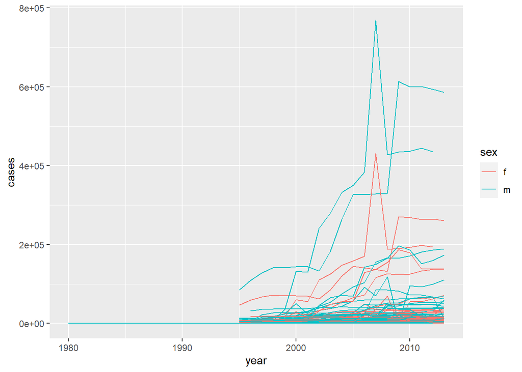

```r
ggplot(oms1, aes(year, cases)) +
  geom_line(aes(group = country_sex, colour = sex))
```

Nos centramos en los datos desde 1995…

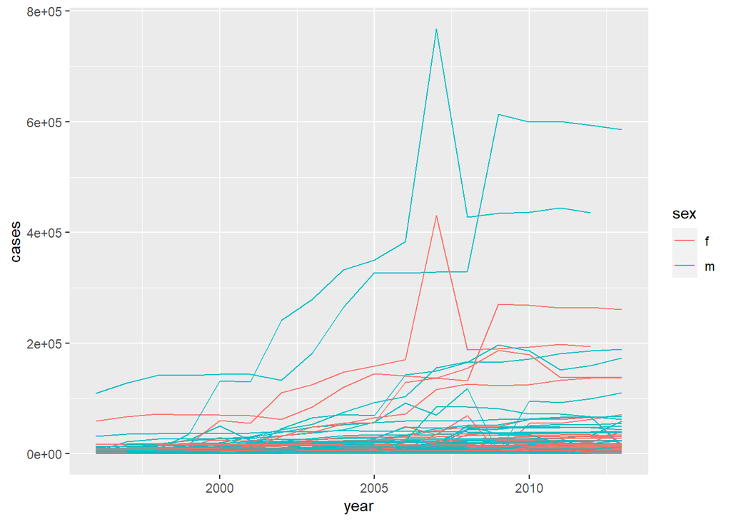

```r
oms2 <- oms1 %>%
  filter(year > 1995)

ggplot(oms2, aes(year, cases)) +
  geom_line(aes(group = country_sex, colour = sex))
```

También podemos selecionar unicamente aquellos con un mayor número de casos…

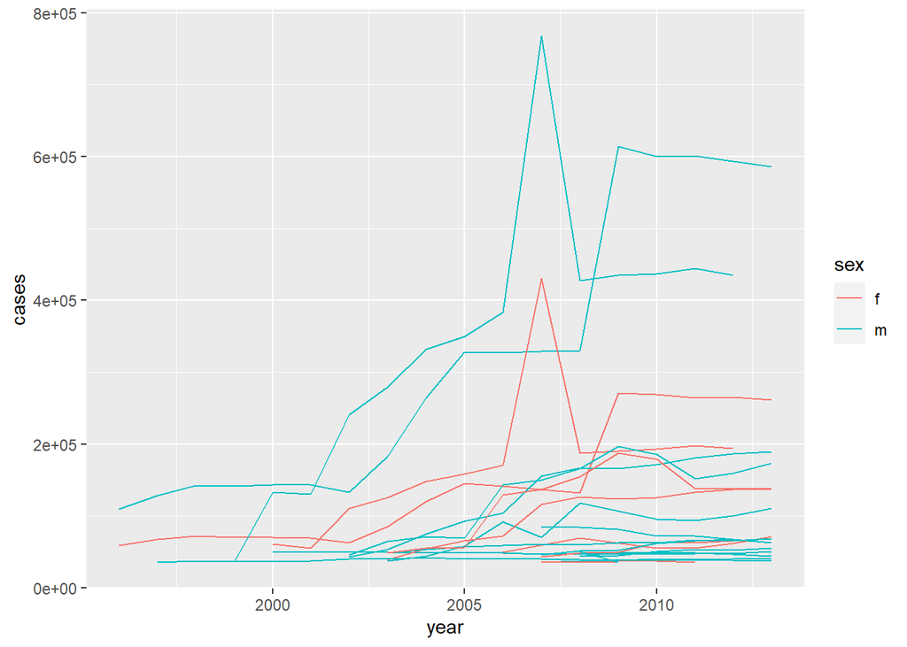

```r
oms3 <- oms2 %>%
   filter(cases > 35000)

ggplot(oms3, aes(year, cases)) +
  geom_line(aes(group = country_sex, colour = sex))
```